# ANNNI phase diagram under CNOT-target depolarizing noise

**Q-SITE Hacks 2026, Scientific Open Challenge.** Team: Benjamin, Dimitri, Yan, Frederick.

$$H=-\sum_i Z_iZ_{i+1}+\kappa\sum_i Z_iZ_{i+2}-h\sum_i X_i$$ Here $Z$ and $X$ are Pauli operators, $J_1=1$, and the ring is **periodic** (N nearest-neighbour and N next-nearest-neighbour bonds).

**Diagnostics.** $C(r)=\frac1N\sum_i\langle Z_iZ_{i+r}\rangle$, $S(q)=\frac1N\sum_{ij}e^{iq(i-j)}\langle Z_iZ_j\rangle$ (the self-terms $C_{ii}=1$ are kept) and $m_x=\frac1N\sum_i\langle X_i\rangle$. The order parameters subtract the uncorrelated floor: $O_F=(S(0)-1)/(N-1)$ and $O_A=(S(\pi/2)-1)/(N/2-1)$.

**Noise model.** `qml.DepolarizingChannel(p)` acts on the **target** qubit immediately after **every** CNOT, simulated on `default.mixed`. It is a single-qubit channel, not a two-qubit one.

**Noise protocol.** Circuit parameters are optimised once at p=0. The same circuits are then evaluated at p = 0, 0.01 and 0.05 with identical thresholds (fixed-parameter degradation).

**Overlays.** The Ising curve is a second-order estimate; the PT (lower) and KT (upper) curves are empirical 1.05 fits. They are thermodynamic references, not finite-ring labels. Citations such as [Sxx] refer to `team/literature/`.

The notebook regenerates every figure from cached arrays in `team/results/`. Set `RECOMPUTE=True` to rerun the scan CLIs, which is slow; the laptop and Mac commands are in `team/README.md`.

```python
import os, sys, json, csv, subprocess
for v in ["OMP_NUM_THREADS","OPENBLAS_NUM_THREADS","MKL_NUM_THREADS"]: os.environ[v]="1"
from pathlib import Path
TEAM = Path.cwd().resolve().parent if Path.cwd().name == "notebooks" else Path.cwd().resolve()
SRC = TEAM / "src"; RES = TEAM / "results"; FIG = RES / "figures"; AN = RES / "analysis"
sys.path.insert(0, str(SRC))
from IPython.display import Image, display
import numpy as np
import annni_core as ac, scan_io as sio, phase_analysis as pa
RECOMPUTE = False      # True: rerun all scans (hours on one core; use the sharded CLIs instead)
print(json.dumps(ac.software_versions(), indent=1))
def show(name, width=900): display(Image(filename=str(FIG / name), width=width))
def js(name): return json.loads((AN / name).read_text())
```

```
{
 "python": "3.14.7",
 "platform": "Linux-6.8.0-138-generic-aarch64-with-glibc2.35",
 "numpy": "2.5.3",
 "scipy": "1.18.1",
 "pennylane": "0.44.1",
 "matplotlib": "3.11.2"
}
```

## 1. Validation

The saved validation reports are shown below. Rerun them with `python src/validate_core.py` and `python src/validate_circuits.py`; each exits non-zero on failure.

```python
core = json.loads((RES/"validation"/"core_validation.json").read_text())
circ = json.loads((RES/"validation"/"circuit_validation.json").read_text())
for k in ["H_vs_starter_and_pennylane_maxabs","bond_counts_N8_periodic","eigsh_vs_dense_maxdE","eigsh_max_residual","eigsh_max_orth_err",
          "ferro_S0","cat_S0","antiphase_Spi2","plus_mx","mixed_mx","hI_0","starter_hI_0_bug"]: print(f"{k:38s} {core[k]}")
for k in ["L4_state_vs_default.qubit","L4_adjoint_vs_fd","L4_p0.05_rho_vs_default.mixed","L4_p0_mixed_vs_pure","L4_cnots","L4_channels","L4_placement_ok","HVA_L4_cnots","HVA_L4_channels","HVA_L4_p","HVA_L4_placement_ok",
          "terminal_p0.05_Sq_formula_err"]: print(f"{k:38s} {circ[k]}")
import hva, circuits as cc
g = np.random.default_rng(3).uniform(-1,1,(4,3))
rho_np = hva.gate_density_matrix(g, 8, 4, 0.05); rho_pl = np.array(hva.pennylane_qnode(8, 4, 0.05)(g))
print("HVA N=8 L=4 p=0.05: NumPy engine vs default.mixed max|Δρ| =", np.abs(rho_np-rho_pl).max(), "; CNOTs =", hva.n_cnots(8,4))
```

```
H_vs_starter_and_pennylane_maxabs      7.105427357601002e-15
bond_counts_N8_periodic                [8, 8]
eigsh_vs_dense_maxdE                   4.796163466380676e-14
eigsh_max_residual                     5.573920938945778e-14
eigsh_max_orth_err                     7.993605777301127e-15
ferro_S0                               8.0
cat_S0                                 8.000000000000002
antiphase_Spi2                         4.0
plus_mx                                1.0
mixed_mx                               0.0
hI_0                                   1.0
starter_hI_0_bug                       0.0
L4_state_vs_default.qubit              0.0
L4_adjoint_vs_fd                       2.5416829751989667e-10
L4_p0.05_rho_vs_default.mixed          1.470698562933137e-14
L4_p0_mixed_vs_pure                    2.998989945268704e-14
L4_cnots                               32
L4_channels                            32
L4_placement_ok                        True
HVA_L4_cnots                           128
HVA_L4_channels                        128
HVA_L4_p                               [0.05]
HVA_L4_placement_ok                    True
terminal_p0.05_Sq_formula_err          2.220446049250313e-15
```

```
HVA N=8 L=4 p=0.05: NumPy engine vs default.mixed max|Δρ| = 2.025810075283883e-14 ; CNOTs = 128
```

## 2. Scans (sharded CLIs) and merge validation

Every scan stores one row file per κ row, and each row is a complete, warm-started sweep in h. The merge step checks that no row is missing or duplicated and that every row carries the same metadata. The discontinuity check flags any anomalous jump between neighbouring rows, which is also where shard boundaries fall.

```python
if RECOMPUTE:
    py = sys.executable
    for cmd in [["ed_scan.py","--n","8"],["ed_scan.py","--n","10"],["ed_scan.py","--n","12"],
                ["ed_scan.py","--n","8","--nk","21","--nh","401","--hmin","0.005"],["ed_scan.py","--n","10","--nk","21","--nh","401","--hmin","0.005"],
                ["ed_scan.py","--n","12","--nk","21","--nh","401","--hmin","0.005"],["vqe_scan.py"],["noisy_eval.py","--mode","pennylane"],
                ["noisy_eval.py","--mode","extras"]]:
        subprocess.run([py, str(SRC/cmd[0])]+cmd[1:], check=True)
for scan, nr in [("ed_N8_pbc_31x31",31),("ed_N10_pbc_31x31",31),("ed_N12_pbc_31x31",31),("ed_N8_pbc_21x401",21),("ed_N12_pbc_21x401",21),
                 ("vqe_hva_N8_L4_31x31",31),("noisy_hva_N8_L4_31x31",31),("noisy_extras_hva_N8_L4_31x31",31)]:
    metas, d, info = sio.merge_rows(scan, nr)
    key = "Sq" if "Sq" in d else next(k for k in sorted(d) if k.endswith("_Sq"))
    rep = sio.boundary_discontinuity_report(d[key][..., 0], key+"[q=0]")
    print(f"{scan:32s} rows={len(metas)} version-sets={info['n_version_sets']} flagged-row-pairs={rep['flagged_row_pairs']} max/median jump={rep['max_row_jump']:.3f}/{rep['median_row_jump']:.3f}")
```

```
ed_N8_pbc_31x31                  rows=31 version-sets=1 flagged-row-pairs=[11, 12, 13, 14] max/median jump=7.254/0.511
ed_N10_pbc_31x31                 rows=31 version-sets=1 flagged-row-pairs=[11, 12, 13, 14] max/median jump=8.999/0.673
ed_N12_pbc_31x31                 rows=31 version-sets=1 flagged-row-pairs=[11, 12, 13, 14] max/median jump=11.362/0.941
```

```
ed_N8_pbc_21x401                 rows=21 version-sets=1 flagged-row-pairs=[7, 8, 9] max/median jump=7.415/0.622
ed_N12_pbc_21x401                rows=21 version-sets=1 flagged-row-pairs=[6, 7, 8, 9] max/median jump=11.658/0.881
vqe_hva_N8_L4_31x31              rows=31 version-sets=1 flagged-row-pairs=[11, 12, 13, 14] max/median jump=7.015/0.477
noisy_hva_N8_L4_31x31            rows=31 version-sets=1 flagged-row-pairs=[14] max/median jump=3.419/0.431
```

```
noisy_extras_hva_N8_L4_31x31     rows=31 version-sets=1 flagged-row-pairs=[] max/median jump=0.028/0.011
```

## 3. Clean exact-diagonalisation reference (N=8, 31×31)

Sparse `eigsh` is run with k=6, warm-started along h, plus an independent cold start at every point. The maximum cold−warm energy difference is below 1e-13. When the ground state is degenerate within 1e-8·|E0|, observables are averaged equally over the degenerate subspace. Fidelity is computed between ground subspaces.

The thresholds are calibrated on **anchor regions that follow from the limiting cases, not from the overlay curves**: ferro at κ≤0.2 and h≤0.2, antiphase at κ≥0.8 and h≤0.1, and paramagnet at h≥1.8. Each threshold is the midpoint between the anchor medians.

```
{
 "T_order": 0.5414484146077675,
 "T_mx": 0.4901264808326204,
 "anchor_medians": {
  "order_ordered": 0.998620503021382,
  "order_para": 0.08427632619415296,
  "mx_ordered": 0.03714249572954419,
  "mx_para": 0.9431104659356966
 },
 "anchor_counts": {
  "ferro": 28,
  "antiphase": 14,
  "para": 124
 },
 "anchor_rule": "ferro kappa<=0.2&h<=0.2; antiphase kappa>=0.8&h<=0.1; para h>=1.8; thresholds = midpoints of anchor medians"
}
label counts {'ferro': 142, 'antiphase': 133, 'paramagnet': 683, 'unpolarised': 3} ambiguous 60
```

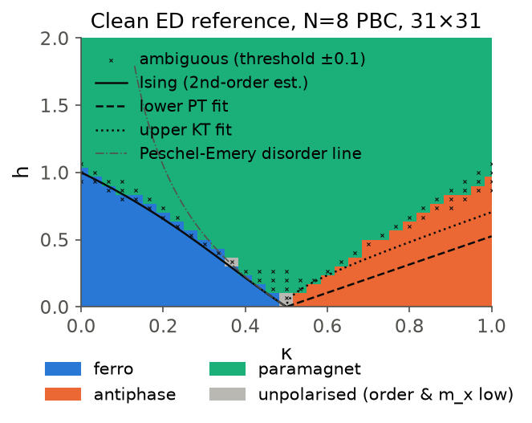

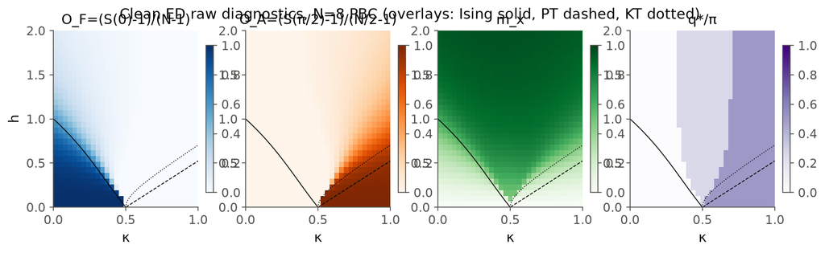

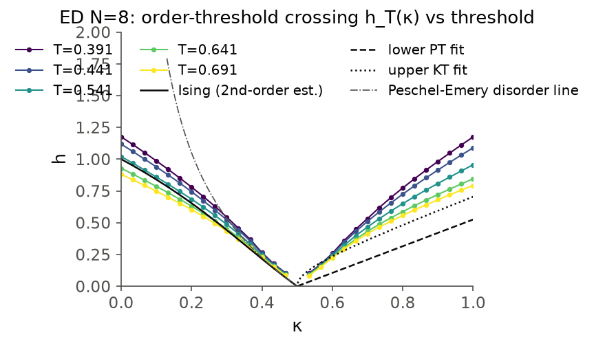

```python
import fig_clean; fig_clean.main()
show("fig_ed_phase_N8.png", 520); show("fig_ed_observables_N8.png"); show("fig_ed_threshold_sensitivity_N8.png", 520)
```

An intermediate q* at high field (q*=π/4 at N=8) lies beyond the Peschel–Emery disorder line inside the gapped paramagnet [S10], so it is **not** labelled floating.

## 4. Circuit preparation: Hamiltonian-variational ansatz (HVA) [S30]

The ansatz starts from $|+\rangle^{N}$ and applies L layers of $e^{-ib\sum X}e^{-ic\sum ZZ_{nnn}}e^{-ia\sum ZZ_{nn}}$, giving 3L parameters. Each ZZ bond compiles to CNOT–RZ–CNOT, so there are 4NL = 128 CNOTs at N=8, L=4.

**Why this ansatz:** a hardware-efficient RY/CNOT ring stalled at 1–3 % energy error near the boundaries even at L=6 (see `src/vqe.py`, benchmark in the report). The HVA preserves translation and parity symmetry, so it can represent the symmetric finite-ring ground state.

**Optimisation:** L-BFGS-B with an exact adjoint gradient. Each κ row is swept forward and backward in h with warm starts, the lower-energy branch is kept, and a repair pass follows. Four random starts are used at h=0 and two at h=2.

[output not shown]

```
{
 "max_relE": 0.06704967420920419,
 "median_relE": 3.868102164902152e-05,
 "frac_F_below_0.9": 0.014568158168574402,
 "median_1mF": 5.332276597558305e-05,
 "max_dSq": 3.284183942300149,
 "median_dSq": 0.0031664457600806273,
 "label_disagreement_count": 11,
 "label_disagreement_frac": 0.011446409989594173,
 "p0_mixed_vs_pure_note": "p=0 row uses exact pure circuit state; default.mixed p=0 agreement validated to 3e-14 in circuit_validation.json",
 "branch_disagreement_max": 6.156704255433931
}
{
 "contraction_p0.01": {
  "median": 0.600808497388946,
  "p10": 0.4949107118486504,
  "p90": 0.7048045718558456
 },
 "frac_ED_ferro_kept_p0.01": 0.0,
 "frac_ED_ferro_kept_parityver_p0.01": 0.11971830985915492,
 "frac_ED_antiphase_kept_p0.01": 0.45864661654135336,
 "frac_ED_antiphase_kept_parityver_p0.01": 0.6917293233082706,
 "frac_ED_paramagnet_kept_p0.01": 0.8887262079062958,
 "frac_ED_paramagnet_kept_parityver_p0.01": 0.9370424597364568,
 "accept_parity_p0.01_median": 0.7117772039221536,
 "purity_p0.01_median": 0.15903515642772628,
 "mx_ratio_p0.01_median_para": 0.6991627834085227,
 "contraction_p0.05": {
  "median": 0.08509612787041572,
  "p10": 0.03899866089273858,
  "p90": 0.16569405606431065
 },
 "frac_ED_ferro_kept_p0.05": 0.0,
 "frac_ED_ferro_kept_parityver_p0.05": 0.0,
 "frac_ED_antiphase_kept_p0.05": 0.0,
 "frac_ED_antiphase_kept_parityver_p0.05": 0.0,
 "frac_ED_paramagnet_kept_p0.05": 0.0,
 "frac_ED_paramagnet_kept_parityver_p0.05": 0.0,
 "accept_parity_p0.05_median": 0.5060439895973744,
 "purity_p0.05_median": 0.004743207205173005,
```

[output cut: 94 more lines]

```
{'kappa': 0.933, 'order': 'antiphase', 'prep_unreliable_frac_row': 0.0, 'h_T_ED': np.float64(0.859), 'h_T_p0.0': np.float64(0.862), 'h_D_p0.0': np.float64(0.778), 'h_T_p0.01': np.float64(0.38), 'h_D_p0.01': np.float64(0.659), 'h_T_p0.05': np.float64(nan), 'h_D_p0.05': np.float64(0.638)}
{'kappa': 0.967, 'order': 'antiphase', 'prep_unreliable_frac_row': 0.0, 'h_T_ED': np.float64(0.908), 'h_T_p0.0': np.float64(0.911), 'h_D_p0.0': np.float64(0.796), 'h_T_p0.01': np.float64(nan), 'h_D_p0.01': np.float64(0.798), 'h_T_p0.05': np.float64(nan), 'h_D_p0.05': np.float64(0.919)}
{'kappa': 1.0, 'order': 'antiphase', 'prep_unreliable_frac_row': 0.0, 'h_T_ED': np.float64(0.956), 'h_T_p0.0': np.float64(0.958), 'h_D_p0.0': np.float64(0.832), 'h_T_p0.01': np.float64(nan), 'h_D_p0.01': np.float64(0.819), 'h_T_p0.05': np.float64(nan), 'h_D_p0.05': np.float64(0.792)}
{
 "max_relE": 0.06704967420920419,
 "median_relE": 3.868102164902152e-05,
 "frac_F_below_0.9": 0.014568158168574402,
 "median_1mF": 5.332276597558305e-05,
 "max_dSq": 3.284183942300149,
 "median_dSq": 0.0031664457600806273,
 "label_disagreement_count": 11,
 "label_disagreement_frac": 0.011446409989594173,
 "p0_mixed_vs_pure_note": "p=0 row uses exact pure circuit state; default.mixed p=0 agreement validated to 3e-14 in circuit_validation.json",
 "branch_disagreement_max": 6.156704255433931
}
```

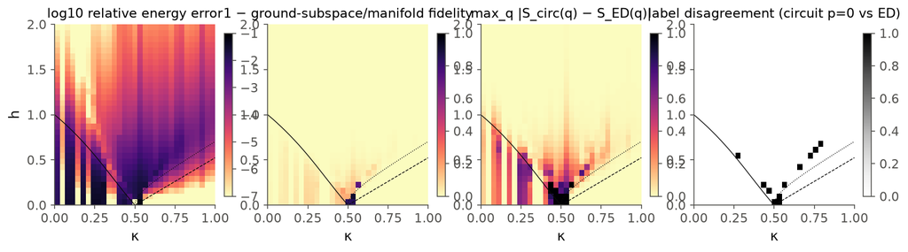

```python
import fig_noise; fig_noise.main()
print(json.dumps(js("prep_quality_N8_L4.json"), indent=1)); show("fig_circuit_vs_ed.png")
```

## 5. Required phase diagrams (fixed parameters, p = 0, 0.01, 0.05)

Panel (a) uses the fixed clean-ED thresholds. Panel (b) uses a threshold-free relative-dominance label, argmax(O_F, O_A, m_x²). Under uniform *terminal* depolarisation all three quantities contract by the same factor a^{2m} [S28], so label (b) is exactly noise-invariant in that benchmark; any change it shows reveals circuit-specific (interleaved) noise action.

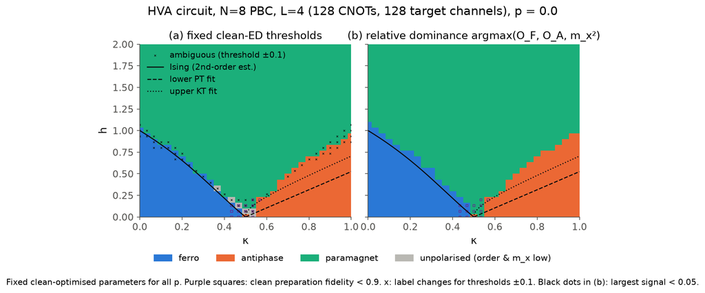

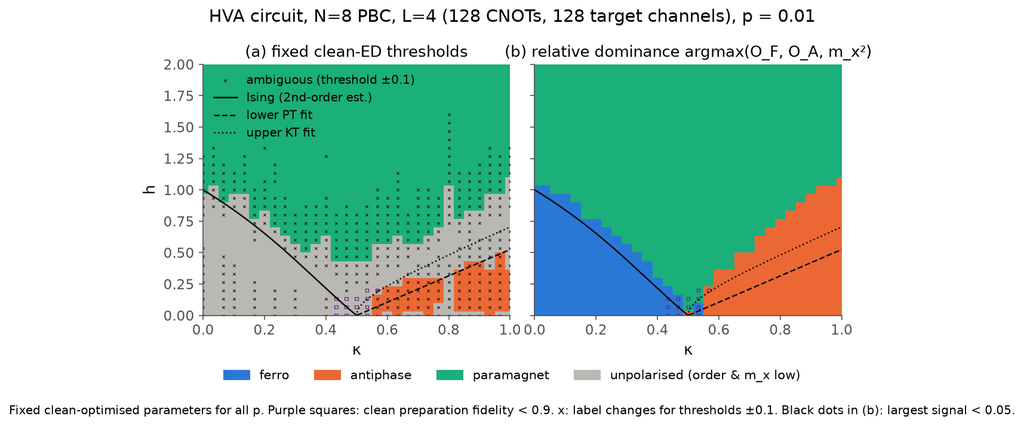

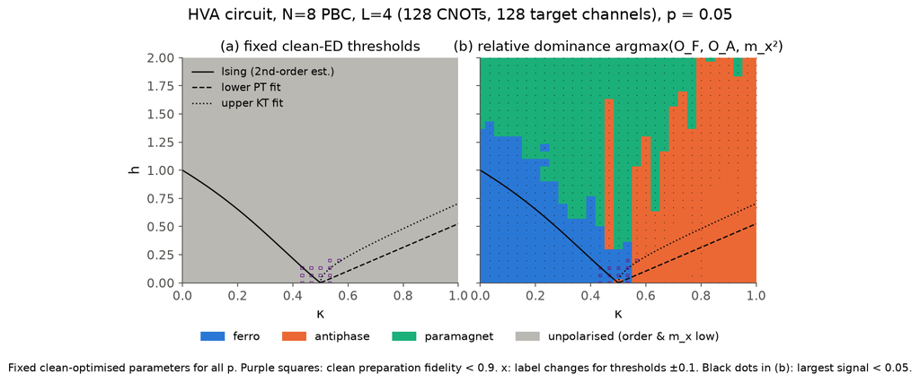

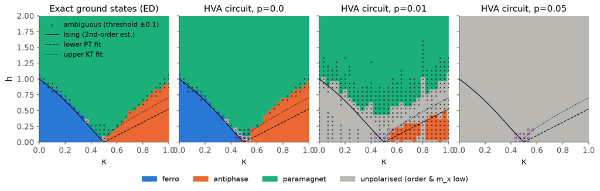

```
{
 "contraction_p0.01": {
  "median": 0.600808497388946,
  "p10": 0.4949107118486504,
  "p90": 0.7048045718558456
 },
 "frac_ED_ferro_kept_p0.01": 0.0,
 "frac_ED_ferro_kept_parityver_p0.01": 0.11971830985915492,
 "frac_ED_antiphase_kept_p0.01": 0.45864661654135336,
 "frac_ED_antiphase_kept_parityver_p0.01": 0.6917293233082706,
 "frac_ED_paramagnet_kept_p0.01": 0.8887262079062958,
 "frac_ED_paramagnet_kept_parityver_p0.01": 0.9370424597364568,
 "accept_parity_p0.01_median": 0.7117772039221536,
 "purity_p0.01_median": 0.15903515642772628,
 "contraction_p0.05": {
  "median": 0.08509612787041572,
  "p10": 0.03899866089273858,
  "p90": 0.16569405606431065
 },
 "frac_ED_ferro_kept_p0.05": 0.0,
 "frac_ED_ferro_kept_parityver_p0.05": 0.0,
 "frac_ED_antiphase_kept_p0.05": 0.0,
 "frac_ED_antiphase_kept_parityver_p0.05": 0.0,
 "frac_ED_paramagnet_kept_p0.05": 0.0,
 "frac_ED_paramagnet_kept_parityver_p0.05": 0.0,
 "accept_parity_p0.05_median": 0.5060439895973744,
 "purity_p0.05_median": 0.004743207205173005,
 "frac_ED_ferro_kept_p0.0": 0.9929577464788732,
 "frac_ED_antiphase_kept_p0.0": 0.9849624060150376,
 "frac_ED_paramagnet_kept_p0.0": 0.9897510980966325
}
```

```python
for p in (0.0, 0.01, 0.05): show(f"phase_diagram_p{p}.png", 820)
show("fig_phase_diagrams_all.png")
s = js("noise_summary_N8_L4.json"); print(json.dumps({k: v for k, v in s.items() if "kept" in k or "contraction" in k or "purity" in k or "accept" in k}, indent=1))
```

## 6. Quantitative noise analysis

The shift is δh(κ,p) = h_b(same circuit, p) − h_b(same circuit, 0), and preparation bias is reported separately as h_b(circuit, 0) − h_b(ED). The estimators are h_T (crossing of the fixed threshold), h_D (maximum of −dO/dh) and h_R (the relative-dominance boundary).

```
      kappa       order      h_T_ED prep_bias_h_T    h_T_p0.0   h_T_p0.01    h_D_p0.0  dh_D_p0.01  dh_D_p0.05    h_R_p0.0  dh_R_p0.01  dh_R_p0.05
     0.0000       ferro      1.0200     -0.0077      1.0123         nan      0.9574      0.0203      0.0960      1.1000     -0.0667      0.2667
     0.1000       ferro      0.8592     -0.0192      0.8400         nan      0.8663     -0.0074     -0.2883      0.9000      0.0667      0.4000
     0.2000       ferro      0.6849     -0.0002      0.6847         nan      0.6533      0.0265      0.6391      0.7667      0.0000      0.3333
     0.3000       ferro      0.4868     -0.0155      0.4713         nan      0.4690      0.0149      0.1852      0.5667      0.0000      0.1333
     0.4000       ferro      0.2458      0.0001      0.2459         nan      0.2481      0.0025      0.0058      0.3000      0.0000      0.4667
     0.5000   antiphase         nan         nan      0.0273         nan      0.0000      0.0000      0.0000      0.0333      0.0000      0.2667
     0.6333   antiphase      0.3227     -0.0193      0.3035      0.2628      0.3017     -0.0015     -0.0029      0.3000      0.0667      0.3333
     0.7333   antiphase      0.5312      0.0124      0.5437      0.3245      0.5225     -0.0003      0.0413      0.5667      0.0667      1.1333
     0.8333   antiphase      0.7054      0.0056      0.7109         nan      0.6462     -0.0008      0.0728      0.7667      0.0667      1.2000
     0.9333   antiphase      0.8587      0.0037      0.8624      0.3803      0.7777     -0.1189     -0.1393      0.9000      0.1333      0.9333
{
 "dE_rel": 0.0032094210583099468,
 "h_T_p0.0": 0.007362773178871046,
 "h_D_p0.0": 0.014877836075091702,
 "h_D_p0.01": 0.012840793918947463,
 "h_D_p0.05": 0.08503016842357075,
 "h_T_p0.01": null,
 "dh_D_p0.01": 0.011247628236152107
}
```

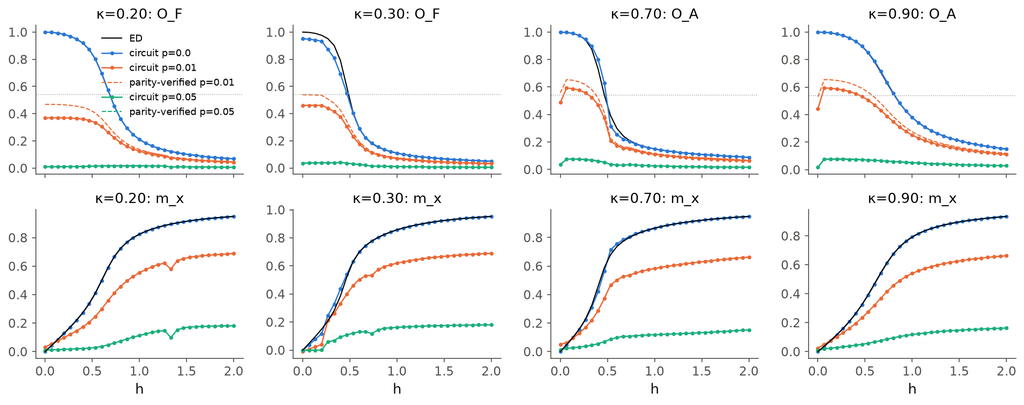

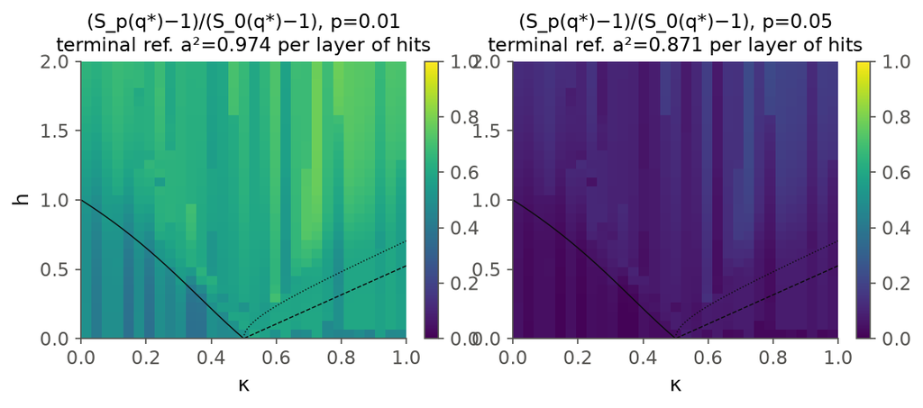

```python
rows = list(csv.DictReader(open(AN/"boundary_shifts_circuit_N8_L4.csv")))
cols = ["kappa","order","h_T_ED","prep_bias_h_T","h_T_p0.0","h_T_p0.01","h_D_p0.0","dh_D_p0.01","dh_D_p0.05","h_R_p0.0","dh_R_p0.01","dh_R_p0.05"]
print(" ".join(f"{c:>11s}" for c in cols))
for r in rows[::3]: print(" ".join(f"{r[c]:>11s}" for c in cols))
print(json.dumps(js("seed_uncertainty_N8_L4.json")["median_abs_seed_difference"], indent=1))
show("fig_noise_cuts.png"); show("fig_contraction.png", 700)
```

### Mechanism: exact first-order channel-insertion responses [S28]

d⟨O⟩/dp at p=0 equals the sum over all 128 channel locations of Tr{O_g L_t(ρ_g)}. Every location is evaluated separately and the sum is resolved by layer. For comparison, the terminal-equivalent value with 16 target hits per site would be d ln O/dp = −8·16/3 ≈ −43 for pair correlators and −21 for m_x.

```python
ins = js("insertion_response_N8_L4.json")
for name, v in ins.items():
    print(f"{name:34s} O_F,O_A,m_x={np.round(v['O_F,O_A,m_x (p=0)'],3)}  dlnO/dp={np.round(v['relative dlnO/dp'],1)}  by layer (dominant O)={ {k: np.round(x,1).tolist() for k,x in v['by_layer'].items()} }")
```

```
ferro (0.2,0.2)                    O_F,O_A,m_x=[ 0.984 -0.328  0.127]  dlnO/dp=[-99.4 -77.6 -16.6]  by layer (dominant O)={'layer1': [-27.1, 7.7, 1.4], 'layer2': [-27.5, 7.2, -0.8], 'layer3': [-25.8, 5.6, -1.5], 'layer4': [-17.4, 5.0, -1.1]}
ferro near boundary (0.2,0.6)      O_F,O_A,m_x=[ 0.697 -0.242  0.499]  dlnO/dp=[-84.7 -65.6 -50.8]  by layer (dominant O)={'layer1': [-15.7, 4.4, -6.7], 'layer2': [-16.2, 4.3, -7.8], 'layer3': [-15.5, 3.6, -6.4], 'layer4': [-11.7, 3.6, -4.4]}
antiphase (0.8,0.2)                O_F,O_A,m_x=[-0.14   0.983  0.132]  dlnO/dp=[-61.3 -69.2  16.6]  by layer (dominant O)={'layer1': [2.7, -22.4, 1.7], 'layer2': [2.7, -19.6, 1.0], 'layer3': [1.7, -15.4, 0.5], 'layer4': [1.5, -10.6, -1.0]}
antiphase near boundary (0.8,0.6)  O_F,O_A,m_x=[-0.095  0.67   0.578]  dlnO/dp=[-62.8 -69.9 -52.8]  by layer (dominant O)={'layer1': [1.8, -15.9, -9.2], 'layer2': [2.0, -14.5, -10.8], 'layer3': [1.2, -9.1, -5.6], 'layer4': [1.0, -7.4, -4.9]}
paramagnet (0.3,1.5)               O_F,O_A,m_x=[ 0.066 -0.018  0.926]  dlnO/dp=[-43.6 -93.3 -32.1]  by layer (dominant O)={'layer1': [-0.5, 0.3, -7.5], 'layer2': [-0.8, 0.6, -7.4], 'layer3': [-0.7, 0.5, -7.5], 'layer4': [-0.9, 0.2, -7.4]}
paramagnet (0.8,1.5)               O_F,O_A,m_x=[-0.021  0.152  0.914]  dlnO/dp=[-71.5 -39.2 -48. ]  by layer (dominant O)={'layer1': [0.6, -2.8, -12.9], 'layer2': [0.6, -0.9, -15.1], 'layer3': [0.2, -0.9, -8.2], 'layer4': [0.2, -1.4, -7.7]}
```

## 7. Finite size (clean ED, N = 8, 10, 12) and floating-phase evidence

```
{
"8": {
"h_T": [
1.02,
0.941,
0.859,
0.774,
0.684,
0.588,
0.485,
0.372,
0.249,
0.121,
NaN,
0.12,
0.244,
0.361,
0.467,
0.562,
0.649,
0.731,
0.808,
0.883,
0.955
],
"h_D": [
0.972,
0.896,
0.817,
0.735,
0.649,
0.559,
0.463,
0.359,
0.245,
0.121,
NaN,
0.121,
0.242,
0.345,
```

[output cut: 247 more lines]

```
"kappa0.75_N10_qstar_jumps_h": [],
"kappa0.75_N10_min_gap": 0.009814992027779468,
"kappa0.75_N12_qstar_jumps_h": [
0.4788125000000001
],
"kappa0.75_N12_min_gap": 5.709183525937078e-08,
"kappa0.9_N8_qstar_jumps_h": [],
"kappa0.9_N8_min_gap": 7.77746574431859e-06,
"kappa0.9_N10_qstar_jumps_h": [],
"kappa0.9_N10_min_gap": 0.009735846480896093,
"kappa0.9_N12_qstar_jumps_h": [
1.0623500000000001
],
"kappa0.9_N12_min_gap": 2.280003030818989e-08
}
```

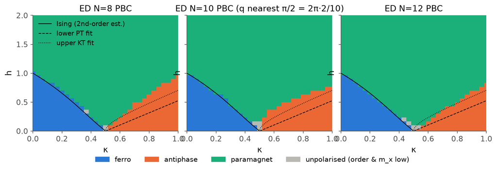

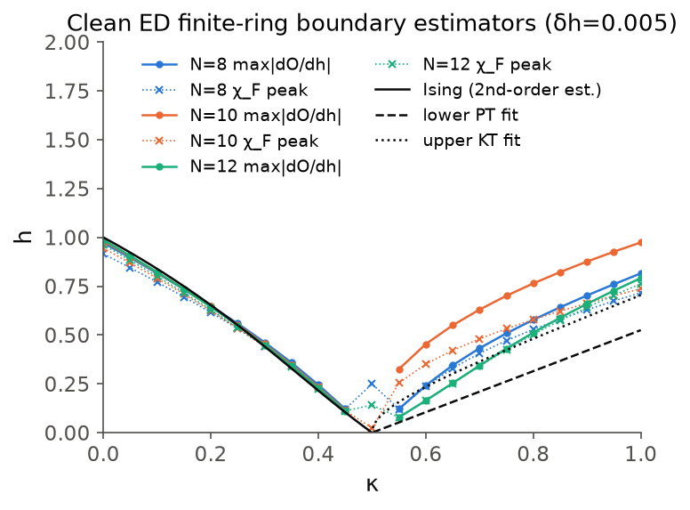

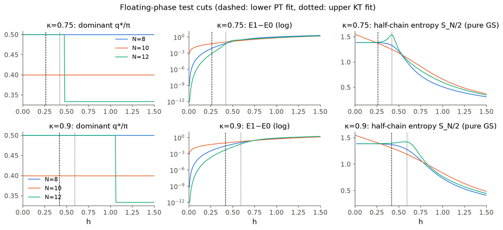

```python
import fig_finite_size; fig_finite_size.main()
show("fig_finite_size_maps.png"); show("fig_finite_size_boundaries.png", 560); show("fig_floating_cuts.png")
```

## 8. Error mitigation (fixed circuit parameters; p=0 truth held out of every fit)

**ZNE:** the noise is scaled linearly (p → λp, λ = 1, 2, 3), with a composed-channel path also tested at p=0.05. Richardson extrapolation is applied to each correlator $C_{ij}$ and each $\langle X_i\rangle$, and $S(q)$ is rebuilt afterwards; labels are never extrapolated.

**Exponential ZNE:** a two-point exponential extrapolation $C_0=C_1^2/C_2$ (λ = 1, 2; linear $2C_1-C_2$ where the two values differ in sign) is also applied to every $C_{ij}$ and to $m_x$. Its variance amplification is $4r^2+r^4$ with $r=C(p)/C(2p)$, reported below.

**Parity verification:** with $P=\prod X_i$ and target sector s=+1, the verified value is $\langle O\rangle_+=(\langle O\rangle+\langle OP\rangle)/(1+\langle P\rangle)$ [S21].

```
{
 "p0.01": {
  "scale_points": [
   0.01,
   0.02
  ],
  "label_agreement_with_clean_circuit": 0.9947970863683663,
  "label_agreement_with_ED": 0.9833506763787722,
  "median_abs_dCij_per_point_mean": 0.004375336474081689,
  "median_abs_dCij_all_elements": 0.0031013000962047815,
  "median_abs_dmx": 0.003415017569570855,
  "raw_median_abs_dCij_per_point_mean": 0.06255931073026226,
  "raw_median_abs_dmx": 0.2588388903648048,
  "fraction_Cij_exponential": 0.9867697339081314,
  "fraction_mx_exponential": 0.9979188345473465,
  "variance_amplification_median_4r2_plus_r4": 18.49999092271781,
  "variance_amplification_p90": 49.22095189997378,
  "label_counts": [
   140,
   137,
   678,
   6
  ]
 },
 "p0.05": {
  "scale_points": [
   0.05,
   0.1
  ],
  "label_agreement_with_clean_circuit": 0.9750260145681582,
  "label_agreement_with_ED": 0.963579604578564,
  "median_abs_dCij_per_point_mean": 0.06187194959003654,
  "median_abs_dCij_all_elements": 0.05238591005676969,
  "median_abs_dmx": 0.08917360782255956,
  "raw_median_abs_dCij_per_point_mean": 0.15447505409040554,
  "raw_median_abs_dmx": 0.7114452529130073,
  "fraction_Cij_exponential": 0.9769213616768248,
  "fraction_mx_exponential": 0.9958376690946931,
  "variance_amplification_median_4r2_plus_r4": 54922.45180597775,
  "variance_amplification_p90": 7903490.360247878,
```

[output cut: 20 more lines]

```
  "kappa_0.800": {
   "order": "antiphase",
   "h_T_clean_circuit": 0.6742833088715903,
   "h_T_expZNE_p0.05": 0.6751064904531175,
   "shift": 0.0008231815815272769
  },
  "kappa_0.900": {
   "order": "antiphase",
   "h_T_clean_circuit": 0.8129150002180673,
   "h_T_expZNE_p0.05": 0.8385028279680612,
   "shift": 0.025587827749993908
  }
 },
 "method": "two-point exponential extrapolation C0=C1^2/C2 (same sign) else 2C1-C2, lambda=1,2 (p, 2p) from noisy_hva and noisy_extras; applied to each C_ij and to m_x; S(q) rebuilt before classifying with the fixed clean-ED thresholds; variance amplification 4r^2+r^4, r=C(p)/C(2p)"
}
```

```
{
 "p0.01_lin_R2": {
  "weights": [
   2.0,
   -1.0
  ],
  "median_abs_Cij_err_raw": 0.06255931073026226,
  "median_abs_Cij_err_mitigated": 0.024704023175073215,
  "median_abs_mx_err_raw": 0.2588388903648048,
  "median_abs_mx_err_mitigated": 0.07624237492951702,
  "label_agreement_with_clean_circuit_raw": 0.7013527575442248,
  "label_agreement_with_clean_circuit_mitigated": 0.951092611862643,
  "variance_amplification_sum_g2": 5.0
 },
 "p0.01_lin_R3": {
  "weights": [
   3.000000000000001,
   -3.0000000000000013,
   1.0000000000000004
  ],
  "median_abs_Cij_err_raw": 0.06255931073026226,
  "median_abs_Cij_err_mitigated": 0.010618770085863203,
  "median_abs_mx_err_raw": 0.2588388903648048,
  "median_abs_mx_err_mitigated": 0.02259301564590832,
  "label_agreement_with_clean_circuit_raw": 0.7013527575442248,
  "label_agreement_with_clean_circuit_mitigated": 0.9802289281997919,
  "variance_amplification_sum_g2": 19.000000000000014
 },
 "p0.05_lin_R2": {
  "weights": [
   2.0,
   -1.0
  ],
  "median_abs_Cij_err_raw": 0.15447505409040554,
  "median_abs_Cij_err_mitigated": 0.13704634795508672,
  "median_abs_mx_err_raw": 0.7114452529130073,
  "median_abs_mx_err_mitigated": 0.6006504394437819,
  "label_agreement_with_clean_circuit_raw": 0.006243496357960458,
  "label_agreement_with_clean_circuit_mitigated": 0.006243496357960458,
  "variance_amplification_sum_g2": 5.0
```

[output cut: 78 more lines]

```
{'kappa': 0.5, 'h_T_p0': 0.027, 'dO_dp_at_crossing': np.float64(-35.625), 'dO_dh_at_crossing': np.float64(-16.813), 'dh_pred_first_order_p0.01': np.float64(-0.021), 'dh_measured_p0.01': nan, 'dh_after_ZNE_R3_p0.01': -0.004, 'dh_parity_verified_p0.01': -0.023, 'dh_pred_first_order_p0.05': np.float64(…
{'kappa': 0.567, 'h_T_p0': 0.227, 'dO_dp_at_crossing': np.float64(-30.752), 'dO_dh_at_crossing': np.float64(-13.615), 'dh_pred_first_order_p0.01': np.float64(-0.023), 'dh_measured_p0.01': -0.087, 'dh_after_ZNE_R3_p0.01': -0.004, 'dh_parity_verified_p0.01': -0.026, 'dh_pred_first_order_p0.05': np.flo…
{'kappa': 0.6, 'h_T_p0': 0.241, 'dO_dp_at_crossing': np.float64(-25.876), 'dO_dh_at_crossing': np.float64(-9.887), 'dh_pred_first_order_p0.01': np.float64(-0.026), 'dh_measured_p0.01': nan, 'dh_after_ZNE_R3_p0.01': -0.003, 'dh_parity_verified_p0.01': -0.028, 'dh_pred_first_order_p0.05': np.float64(-…
{'kappa': 0.633, 'h_T_p0': 0.303, 'dO_dp_at_crossing': np.float64(-30.119), 'dO_dh_at_crossing': np.float64(-10.236), 'dh_pred_first_order_p0.01': np.float64(-0.029), 'dh_measured_p0.01': -0.041, 'dh_after_ZNE_R3_p0.01': -0.004, 'dh_parity_verified_p0.01': -0.029, 'dh_pred_first_order_p0.05': np.flo…
{'kappa': 0.667, 'h_T_p0': 0.428, 'dO_dp_at_crossing': np.float64(-29.374), 'dO_dh_at_crossing': np.float64(-6.41), 'dh_pred_first_order_p0.01': np.float64(-0.046), 'dh_measured_p0.01': nan, 'dh_after_ZNE_R3_p0.01': -0.007, 'dh_parity_verified_p0.01': nan, 'dh_pred_first_order_p0.05': np.float64(-0.…
{'kappa': 0.7, 'h_T_p0': 0.485, 'dO_dp_at_crossing': np.float64(-27.244), 'dO_dh_at_crossing': np.float64(-4.728), 'dh_pred_first_order_p0.01': np.float64(-0.058), 'dh_measured_p0.01': nan, 'dh_after_ZNE_R3_p0.01': -0.008, 'dh_parity_verified_p0.01': -0.107, 'dh_pred_first_order_p0.05': np.float64(-…
{'kappa': 0.733, 'h_T_p0': 0.544, 'dO_dp_at_crossing': np.float64(-26.044), 'dO_dh_at_crossing': np.float64(-2.295), 'dh_pred_first_order_p0.01': np.float64(-0.113), 'dh_measured_p0.01': -0.219, 'dh_after_ZNE_R3_p0.01': -0.016, 'dh_parity_verified_p0.01': -0.131, 'dh_pred_first_order_p0.05': np.floa…
{'kappa': 0.767, 'h_T_p0': 0.612, 'dO_dp_at_crossing': np.float64(-29.843), 'dO_dh_at_crossing': np.float64(-1.98), 'dh_pred_first_order_p0.01': np.float64(-0.151), 'dh_measured_p0.01': nan, 'dh_after_ZNE_R3_p0.01': -0.023, 'dh_parity_verified_p0.01': -0.191, 'dh_pred_first_order_p0.05': np.float64(…
{'kappa': 0.8, 'h_T_p0': 0.674, 'dO_dp_at_crossing': np.float64(-36.191), 'dO_dh_at_crossing': np.float64(-2.501), 'dh_pred_first_order_p0.01': np.float64(-0.145), 'dh_measured_p0.01': nan, 'dh_after_ZNE_R3_p0.01': -0.044, 'dh_parity_verified_p0.01': nan, 'dh_pred_first_order_p0.05': np.float64(-0.7…
{'kappa': 0.833, 'h_T_p0': 0.711, 'dO_dp_at_crossing': np.float64(-25.713), 'dO_dh_at_crossing': np.float64(-1.426), 'dh_pred_first_order_p0.01': np.float64(-0.18), 'dh_measured_p0.01': nan, 'dh_after_ZNE_R3_p0.01': -0.025, 'dh_parity_verified_p0.01': nan, 'dh_pred_first_order_p0.05': np.float64(-0.…
{'kappa': 0.867, 'h_T_p0': 0.763, 'dO_dp_at_crossing': np.float64(-25.635), 'dO_dh_at_crossing': np.float64(-1.219), 'dh_pred_first_order_p0.01': np.float64(-0.21), 'dh_measured_p0.01': nan, 'dh_after_ZNE_R3_p0.01': -0.029, 'dh_parity_verified_p0.01': -0.22, 'dh_pred_first_order_p0.05': np.float64(-…
{'kappa': 0.9, 'h_T_p0': 0.813, 'dO_dp_at_crossing': np.float64(-25.561), 'dO_dh_at_crossing': np.float64(-1.058), 'dh_pred_first_order_p0.01': np.float64(-0.242), 'dh_measured_p0.01': nan, 'dh_after_ZNE_R3_p0.01': -0.03, 'dh_parity_verified_p0.01': nan, 'dh_pred_first_order_p0.05': np.float64(-1.20…
{'kappa': 0.933, 'h_T_p0': 0.862, 'dO_dp_at_crossing': np.float64(-29.702), 'dO_dh_at_crossing': np.float64(-1.118), 'dh_pred_first_order_p0.01': np.float64(-0.266), 'dh_measured_p0.01': -0.482, 'dh_after_ZNE_R3_p0.01': -0.041, 'dh_parity_verified_p0.01': -0.311, 'dh_pred_first_order_p0.05': np.floa…
{'kappa': 0.967, 'h_T_p0': 0.911, 'dO_dp_at_crossing': np.float64(-25.456), 'dO_dh_at_crossing': np.float64(-0.946), 'dh_pred_first_order_p0.01': np.float64(-0.269), 'dh_measured_p0.01': nan, 'dh_after_ZNE_R3_p0.01': -0.036, 'dh_parity_verified_p0.01': nan, 'dh_pred_first_order_p0.05': np.float64(-1…
{'kappa': 1.0, 'h_T_p0': 0.958, 'dO_dp_at_crossing': np.float64(-30.314), 'dO_dh_at_crossing': np.float64(-0.853), 'dh_pred_first_order_p0.01': np.float64(-0.355), 'dh_measured_p0.01': nan, 'dh_after_ZNE_R3_p0.01': -0.056, 'dh_parity_verified_p0.01': -0.373, 'dh_pred_first_order_p0.05': np.float64(-…
```

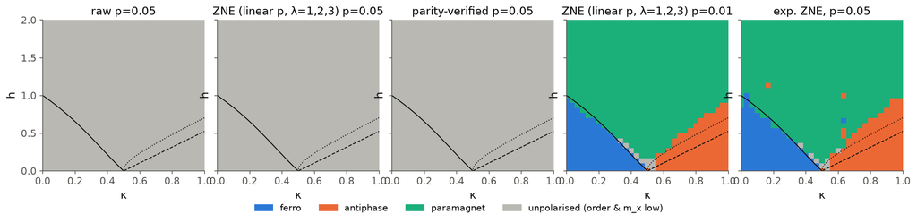

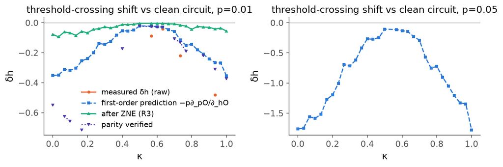

```
anchor rule re-applied at p0.0: T=0.539, T_x=0.491, ferro points=142, agreement with ED=0.986
anchor rule re-applied at p0.01: T=0.266, T_x=0.372, ferro points=142, agreement with ED=0.961
anchor rule re-applied at p0.05: T=0.026, T_x=0.094, ferro points=106, agreement with ED=0.693
```

```python
import fig_mitigation; fig_mitigation.main()
show("fig_mitigation_diagrams.png"); show("fig_shift_prediction.png", 760)
rc = js("recalibrated_thresholds.json")
for k in ("p0.0", "p0.01", "p0.05"):
    v = rc[k]; print(f"anchor rule re-applied at {k}: T={v['T_order']:.3f}, T_x={v['T_mx']:.3f}, ferro points={v['n_ferro']}, agreement with ED={v['agreement_with_ED']:.3f}")
```

## 9. Extensions: depth trade-off, unsupervised classifier, noise-aware re-optimisation, dynamics

These extensions use exactly the same noise model. The **depth** study reruns the fixed-parameter protocol for L = 1–4 on four κ cuts. **k-means** (k=3) is applied to $(S(q)/N, m_x)$ without labels or curves, and the clusters are named from their centroids afterwards. **Re-optimisation** is a separate protocol that minimises $\mathrm{Tr}(H\rho_p)$ at each p, using an exact gradient through the channels.

```
{
"kappa0.200_p0.0": {
"best_L": 4,
"errors": {
"1": 0.24737560023530888,
"2": 0.1686188004753544,
"3": 0.06153688809732084,
"4": 0.00013720854712569264
}
},
"kappa0.200_p0.01": {
"best_L": 3,
"errors": {
"1": 0.2671936397344812,
"2": 0.2269635870589692,
"3": 0.19890100331332788,
"4": 0.23452460499538053
}
},
"kappa0.200_p0.05": {
"best_L": 1,
"errors": {
"1": 0.32773923042416914,
"2": 0.35290796404548574,
"3": 0.38380429774372793,
"4": 0.4057886155721295
}
},
"kappa0.300_p0.0": {
"best_L": 4,
"errors": {
"1": 0.18313148951658334,
"2": 0.13995806296884059,
"3": 0.052568198593901286,
"4": 0.016977327590090484
}
},
"kappa0.300_p0.01": {
"best_L": 3,
"errors": {
```

[output cut: 55 more lines]

```
"2": 0.09720103705865124,
"3": 0.1451254899728893,
"4": 0.2028958681915715
}
},
"kappa0.800_p0.05": {
"best_L": 2,
"errors": {
"1": 0.33839493720730135,
"2": 0.30978729797201926,
"3": 0.38010563615045256,
"4": 0.4127125816415928
}
}
}
```

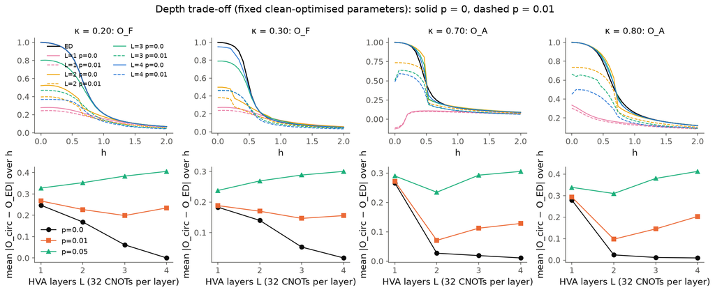

```
{
 "k": 3,
 "features": "S(q)/N for q=0,pi/4,pi/2,3pi/4,pi and m_x (standardised)",
 "cluster_names": {
  "2": "ferro",
  "0": "antiphase",
  "1": "paramagnet"
 },
 "agreement_with_rule_labels_clean_ED": 0.9906347554630593,
 "agreement_noisy_p0.01_vs_clean_kmeans": 0.81789802289282,
 "agreement_noisy_p0.05_vs_clean_kmeans": 0.7107180020811654
}
```

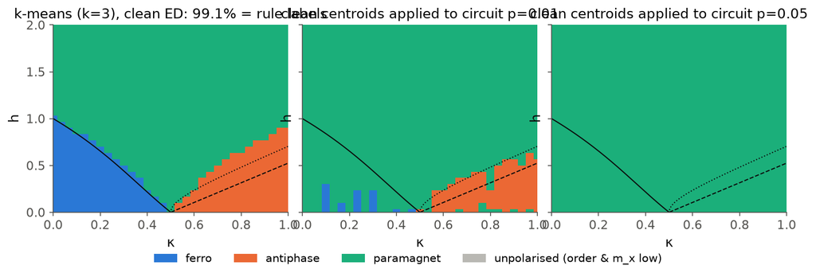

```
6 0.2 {'p0.01': (-0.016, 0.257, 0.273), 'p0.05': (0.007, 0.439, 0.433)}
9 0.3 {'p0.01': (-0.011, 0.174, 0.185), 'p0.05': (-0.003, 0.332, 0.335)}
21 0.7 {'p0.01': (0.005, 0.158, 0.152), 'p0.05': (0.0, 0.341, 0.341)}
24 0.8 {'p0.01': (0.028, 0.225, 0.198), 'p0.05': (0.015, 0.446, 0.43)}
```

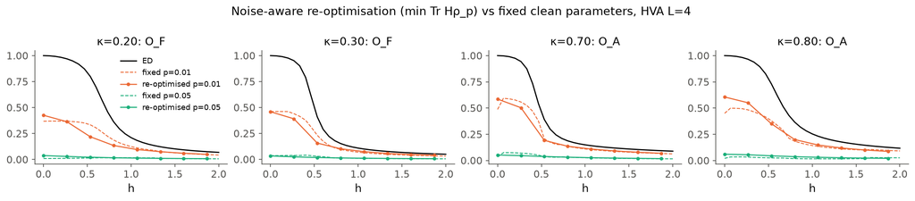

```python
import fig_depth, fig_cluster, fig_reopt
fig_depth.main(); show("fig_depth_tradeoff.png")
fig_cluster.main(); show("fig_kmeans.png")
fig_reopt.main()
if (FIG/"fig_reopt.png").exists(): show("fig_reopt.png")
```

### Quench dynamics (corroboration only)

The ring starts in $|+\rangle^N$ and evolves under first-order Trotter steps; each step is compiled exactly as one HVA layer (32 CNOTs, target noise after every CNOT). We plot the Loschmidt rate $\lambda(t)=-\ln|\langle+|\psi(t)\rangle|^2/N$ and keep the Trotter error (exact vs Trotter) separate from the channel error (Trotter vs noisy Trotter). Rerun with `python src/dynamics.py` (about 1 min).

```
kappa0.2_h0.2    max λ exact=0.570  Trotter err=0.014  channel err (p=0.01)=0.233
kappa0.2_h0.4    max λ exact=0.549  Trotter err=0.035  channel err (p=0.01)=0.288
kappa0.2_h0.6    max λ exact=0.286  Trotter err=0.016  channel err (p=0.01)=0.285
kappa0.2_h0.8    max λ exact=0.190  Trotter err=0.012  channel err (p=0.01)=0.280
kappa0.2_h1.2    max λ exact=0.101  Trotter err=0.013  channel err (p=0.01)=0.271
kappa0.8_h0.2    max λ exact=0.402  Trotter err=0.008  channel err (p=0.01)=0.273
kappa0.8_h0.4    max λ exact=1.049  Trotter err=0.029  channel err (p=0.01)=0.439
kappa0.8_h0.6    max λ exact=0.304  Trotter err=0.027  channel err (p=0.01)=0.298
kappa0.8_h0.8    max λ exact=0.160  Trotter err=0.018  channel err (p=0.01)=0.281
kappa0.8_h1.2    max λ exact=0.106  Trotter err=0.021  channel err (p=0.01)=0.284
```

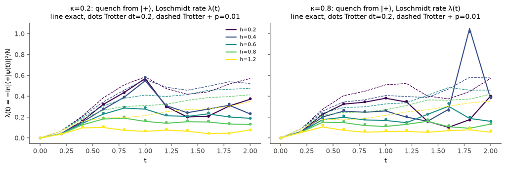

```python
dyn = js("dynamics.json")
for k, v in dyn.items(): print(f"{k:16s} max λ exact={v['max_rate_exact']:.3f}  Trotter err={v['max_trotter_err_rate']:.3f}  channel err (p=0.01)={v['max_channel_err_rate_p0.01']:.3f}")
show("fig_dynamics.png", 800)
```

## 10. Conclusions and limitations

The write-up is `writeup/report.pdf` (source `writeup/report.tex`). The main caveats: N=8–12 rings; overlays are approximate thermodynamic curves; the noisy maps describe prepared-state diagnostics, while the Hamiltonian spectrum itself is unchanged; the full-grid maps use the fixed-parameter protocol, and noise-aware re-optimisation was run on four κ cuts (§9); at p=0.05 linear Richardson ZNE fails, while two-point exponential ZNE recovers the map only at the cost of a very large variance amplification (see `results/analysis/zne_exponential.json`).